# Feature selection analysis

- Show All Code
- Hide All Code
- View Source

Author

André F. B. Menezes, Beatrice Tropea, and Cormac Monaghan

Published

December 20, 2022

```r
library(ggplot2)
library(cowplot)
theme_set(
  theme_cowplot() +
    background_grid() +
    theme(legend.position = "top")
)
```

# 1 Introduction

This document performs two methods of feature selection in order to reduce the number of proteins by selecting only the ones with high biological variability. The first method is based on the decomposition of the variance into technical and biological by nonparametrically modeling the variance intensity as a function of mean intensity. The latter uses the Hedge’s G effect size statistic.

All the analysis considers the processed $\log_2$ intensity matrix performed in the processing steps described here.

# 2 Modeling mean-variance relationship

This approach fits a locally-weighted regression (LOWESS) between the mean-variance relationship of the $\log_2$ normalized intensity for all proteins. We then subtract the variance of each protein by their corresponding fitted values. The remaining values are called biological variability. The `modelGeneVar` function from the `scran` package (Lun, McCarthy, and Marioni 2016) is used.

```r
dec <- scran::modelGeneVar(x = fts[["proteins"]],
                           assay.type = "log2_normalized",
                           parametric = FALSE)

dec[order(dec$bio, decreasing = TRUE), ]
```

```
DataFrame with 1071 rows and 6 columns
            mean     total      tech       bio      p.value          FDR
       <numeric> <numeric> <numeric> <numeric>    <numeric>    <numeric>
P08331   24.9304   5.65438  0.427007   5.22738  2.93643e-92  1.57246e-89
P41407   25.9695   4.99041  0.326158   4.66425 4.46202e-125 4.77882e-122
P76329   24.9034   4.63193  0.430323   4.20161  1.77672e-59  3.80574e-57
P43329   24.5928   4.08985  0.472106   3.61775  1.98402e-37  2.36098e-35
P0A729   25.8942   3.75008  0.332671   3.41741  1.31104e-65  3.51032e-63
...          ...       ...       ...       ...          ...          ...
P0A940   23.9474 0.1616119  0.579544 -0.417932     0.884559     0.915447
P21499   24.3707 0.0839123  0.509463 -0.425550     0.917392     0.919969
P0ADT5   24.2284 0.0935140  0.533361 -0.439847     0.914671     0.918961
P0AFY8   23.8601 0.1080091  0.596016 -0.488006     0.913134     0.918278
P0AA39   22.4817 0.5248826  1.075748 -0.550865     0.802547     0.915447
```

Figure 1 shows the mean-variance relationship with the fitted trend curve in blue. We observe two extreme points greater (lower) than 29 (22).

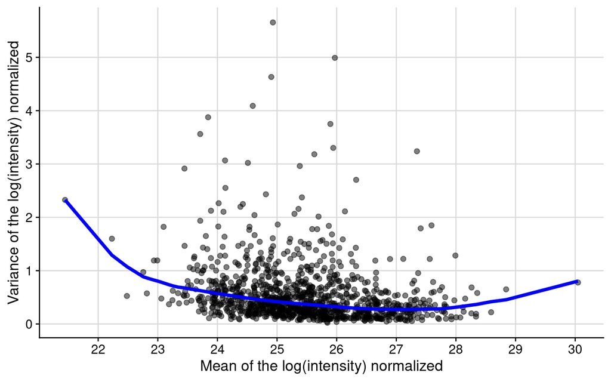

Figure 1: Relationship between the mean-variance of the $\log_2$ intensity. Each point is a protein and the blue curve is the fitted model.

```r
plot_mean_variance <- function(dec) {
  ggplot(dplyr::as_tibble(dec), aes(x = mean, y = total)) +
    geom_point(size = 2, alpha = 0.5) +
    geom_line(aes(y = tech), size = 1.5, col = "blue") +
    scale_x_continuous(breaks = scales::pretty_breaks(8)) +
    scale_y_continuous(breaks = scales::pretty_breaks(8)) +
    labs(x = "Mean of the log(intensity) normalized",
         y = "Variance of the log(intensity) normalized")
}
plot_mean_variance(dec = dec)
```

These two extreme proteins are listed below. Their inclusion could impact the fitted curve. Therefore, we will remove these cases from the analysis.

```r
chosen <- ((dec$mean < 22) | (dec$mean > 29))
to_remove <- rownames(dec)[chosen]
to_remove
```

```
[1] "P0A6A8" "P33937"
```

```r
rowData(fts[["proteins"]][to_remove, ])
```

```
DataFrame with 2 rows and 2 columns
           protein        .n
       <character> <integer>
P0A6A8      P0A6A8         4
P33937      P33937        11
```

```r
assay(fts[["proteins"]][to_remove, ], "intensity")
```

```
         Sample_1  Sample_2  Sample_3   Sample_4   Sample_5   Sample_6
P0A6A8 1108100000 324080000 370240000 2523100000 1031620500 2196400000
P33937        NaN       NaN       NaN     677790        NaN    3823800
         Sample_7  Sample_8  Sample_9  Sample_10  Sample_11  Sample_12
P0A6A8 1679500000 326440000 435820000 1338935000 1200500000 1818090000
P33937   14628000  21379000  18467000     502870        NaN    1275900
        Sample_13  Sample_14  Sample_15
P0A6A8 2554000000 2482100000 2568000000
P33937     743930     934590     749060
```

```r
assay(fts[["proteins"]][to_remove, ], "log2_normalized")
```

```
       Sample_1 Sample_2 Sample_3 Sample_4 Sample_5 Sample_6 Sample_7 Sample_8
P0A6A8  30.6247 28.89924 30.19233 30.58501 29.95668 30.66833 30.26348 28.45135
P33937  22.3048 22.86215 21.59083 20.51234 22.19533 22.24679 22.45014 24.08512
       Sample_9 Sample_10 Sample_11 Sample_12 Sample_13 Sample_14 Sample_15
P0A6A8 28.24246  29.82800  29.99644  30.19061  31.34453  30.69197  30.76294
P33937 22.30163  19.03237  22.87976  19.34934  19.88076  19.82217  20.16071
```

```r
# Removing the two proteins with lower (greater) mean (m < 22 and m > 29)
chosen <- !(rownames(fts[["proteins"]]) %in% to_remove)
fts[["proteins"]] <- fts[["proteins"]][chosen, ]

dec_2 <- scran::modelGeneVar(x = fts[["proteins"]],
                             assay.type = "log2_normalized",
                             parametric = FALSE)
dec_2[order(dec_2$bio, decreasing = TRUE), ]
```

```
DataFrame with 1069 rows and 6 columns
            mean     total      tech       bio     p.value         FDR
       <numeric> <numeric> <numeric> <numeric>   <numeric>   <numeric>
P08331   24.9304   5.65438  0.460203   5.19418 2.37245e-68 1.26807e-65
P41407   25.9695   4.99041  0.354917   4.63549 8.69742e-91 9.29755e-88
P76329   24.9034   4.63193  0.463446   4.16849 3.56479e-44 7.62152e-42
P43329   24.5928   4.08985  0.507987   3.58187 6.43289e-28 7.64085e-26
P0A729   25.8942   3.75008  0.363512   3.38657 3.06072e-47 8.17977e-45
...          ...       ...       ...       ...         ...         ...
P21499   24.3707 0.0839123  0.549147 -0.465235    0.904638    0.907184
P0A940   23.9474 0.1616119  0.628741 -0.467129    0.874403    0.903255
P0ADT5   24.2284 0.0935140  0.578753 -0.485239    0.902321    0.905710
P0AFY8   23.8601 0.1080091  0.643834 -0.535824    0.900664    0.905710
P0AA39   22.4817 0.5248826  1.103418 -0.578535    0.790963    0.903255
```

```r
table(dec_2$bio > 0)
```

```
FALSE  TRUE
  570   499
```

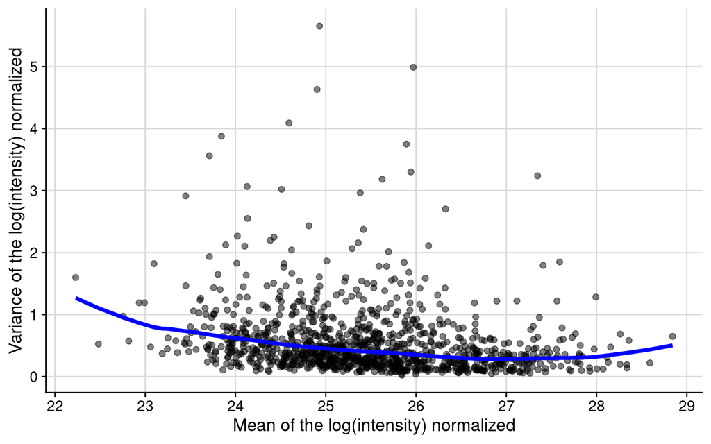

Figure 2: Relationship between the mean-variance of the $\log_2$ intensity after removing some proteins. Each point is a protein and the blue curve is the fitted model.

```r
plot_mean_variance(dec = dec_2)

# Concatenate the decomposition into SE object
if (all.equal(rownames(fts[["proteins"]]), rownames(dec_2)))
  rowData(fts[["proteins"]]) <- cbind(rowData(fts[["proteins"]]), dec_2)
```

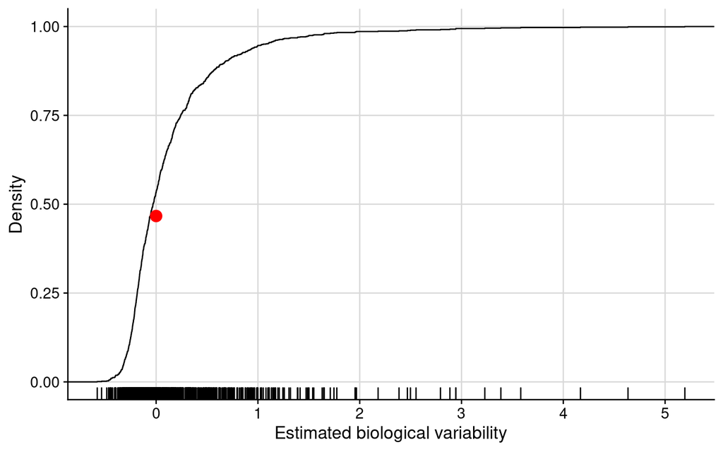

Figure 3: Empirical cumulative distribution of the estimated biological variability.

```r
ggplot(dplyr::as_tibble(dec_2), aes(x = bio)) +
  # geom_density(alpha = 0.4, fill = "grey68") +
  # geom_vline(xintercept = 0, col = "red") +
  stat_ecdf() +
  geom_point(data = data.frame(x = 0, y = mean(dec_2$bio > 0)),
             aes(x = x, y = y), col = "red", size = 4) +
  geom_rug() +
  labs(x = "Estimated biological variability", y = "Density") +
  scale_x_continuous(breaks = scales::pretty_breaks(8))
```

# 3 Effect size statistic

For each comparison (Control vs Treatment) we can see which proteins are up/down regulated in the control and remove them from the treatment because it means that their expression is regulated by physiological gene expression. Typically, Cohen’s D is used for effect size calculation, however was noted to be biased with regard to small sample sizes (Borenstein et al. 2009). To address this we convert Cohen’s D to Hedge’s G by applying a correction factor (Hedges 1981). The statistic is defined by

$$G = J\,\dfrac{\bar{x}_T - \bar{x}_C}{\sqrt{\frac{{s_T^2 + s_C^2}}{2}}}$$
where $\bar{x}_T$ and $\bar{x}_C$ are the mean of the treatment and control groups, $s_T^2$ and $s_C^2$ are the sample standard deviations of each respective group (treatment and control), and $J \approx 1 - \frac{3}{(4\; (n_T + n_G) - 9}$ is the correction factor, with $n_T$ and $n_G$ being the sample size of each respective group (treatment and control).

We use the `hedges_g` function from the `effectsize` package (Ben-Shachar, Lüdecke, and Makowski 2020).

```r
ampicillin <- apply(
  assay(fts[["proteins"]], i = "log2_normalized"), 1,
  function(z)  effectsize::hedges_g(z[1:3], z[10:12])$Hedges_g)

cefotaxime <- apply(
  assay(fts[["proteins"]], i = "log2_normalized"), 1,
  function(x) effectsize::hedges_g(x[4:6], x[10:12])$Hedges_g)

ciprofloxacin <- apply(
  assay(fts[["proteins"]], i = "log2_normalized"), 1,
  function(x) effectsize::hedges_g(x[7:9], x[10:12])$Hedges_g)

impipenem <- apply(
  assay(fts[["proteins"]], i = "log2_normalized"), 1,
  function(x) effectsize::hedges_g(x[13:15], x[10:12])$Hedges_g)

# Organize the results in a data frame
effect_sizes <- data.frame(ampicillin, cefotaxime, ciprofloxacin, impipenem)
colnames(effect_sizes) <- paste0("hedges_g__", colnames(effect_sizes))
head(effect_sizes)
```

```
           hedges_g__ampicillin hedges_g__cefotaxime hedges_g__ciprofloxacin
ACQ41977.1            0.9767493           0.01522159              0.72676641
ACQ41978.1            1.8229212           2.49992030              0.93797761
ACQ42006.1           -1.2573916          -0.62904612             -0.59959901
ACQ42024.1           -0.4676839           1.00331623              1.90903364
ACQ42036.1           -0.5782748          -0.70901112              0.41758865
ACQ42042.1            0.3867355           0.30967900             -0.01888578
           hedges_g__impipenem
ACQ41977.1          -0.1125966
ACQ41978.1          -0.2865368
ACQ42006.1          -0.8926978
ACQ42024.1           2.9455298
ACQ42036.1           0.1255207
ACQ42042.1           0.3601048
```

```r
# Concatenating
if (all.equal(rownames(fts[["proteins"]]), rownames(effect_sizes)))
  rowData(fts[["proteins"]]) <- cbind(rowData(fts[["proteins"]]), effect_sizes)
```

Figure 4 shows the density of the absolute values of the Hedge’s G statistic according to the treatment.

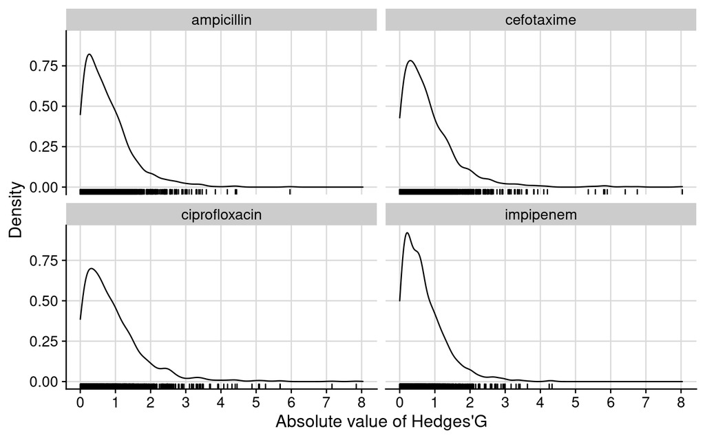

Figure 4: Density of the absolute value of Hedges’G statistics compared with the control for each protein and according to the treatment.

```r
pivotted_ef <- effect_sizes |>
  dplyr::mutate(protein = rownames(effect_sizes)) |>
  tidyr::pivot_longer(cols = -protein, names_to = "hedges_g",
                      values_to = "value") |>
  dplyr::mutate(variable = gsub("hedges_g__", "", hedges_g))
ggplot(pivotted_ef, aes(x = abs(value))) +
  facet_wrap(~variable) +
  geom_density(alpha = 0.4) +
  geom_rug() +
  labs(x = "Absolute value of Hedges'G", y = "Density") +
  scale_x_continuous(breaks = scales::pretty_breaks(8))
```

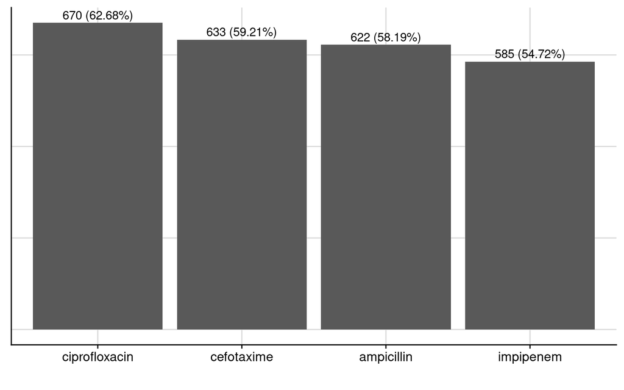

Figure 5: Total of selected proteins by group. The rule of thumb is the absolute value of Hedges greater than 0.5.

```r
total_filtered <- pivotted_ef |>
  dplyr::group_by(variable) |>
  dplyr::summarise(n = sum(abs(value) > 0.5),
                   pct = mean(abs(value) > 0.5),
                   .groups = "drop")
ggplot(total_filtered, aes(x = reorder(variable, -n), y = n)) +
  geom_col() +
  geom_text(aes(label = paste0(n, " (", round(100 * pct, 2), "%)")),
            vjust = -0.4) +
  labs(x = "", y = "") +
  theme(axis.text.y = element_blank(), axis.title.y = element_blank(),
        axis.ticks.y = element_blank())
```

# 4 Comparison

Finally, we plot in Figure 6 the intersection of proteins selected between the two methods.

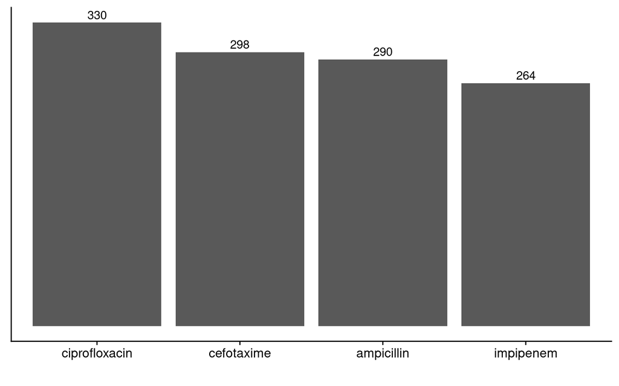

Figure 6: Total of intersect proteins of the feature selection method by group.

```r
chosen_var <- rownames(dec_2)[dec_2$bio > 0]
list_df <- list()
j <- 1L
for (g in unique(pivotted_ef$variable)) {
  chosen_hedges_g <- pivotted_ef[pivotted_ef$variable == g &
                                   abs(pivotted_ef$value) > 0.5, ]$protein
  list_df[[j]] <- data.frame(
    group = g, n = length(intersect(chosen_var, chosen_hedges_g)))
  j <- j + 1L
}
data_intersect <- do.call(rbind, list_df)
ggplot(data_intersect, aes(x = reorder(group, -n), y = n)) +
  geom_col() +
  geom_text(aes(label = n), vjust = -0.4) +
  labs(x = "", y = "") +
  theme(axis.text.y = element_blank(), axis.title.y = element_blank(),
        axis.ticks.y = element_blank(), panel.grid = element_blank())
```

```r
saveRDS(fts, file = "../data/fts_processed.rds")
```

## References

Ben-Shachar, Mattan S., Daniel Lüdecke, and Dominique Makowski. 2020. “effectsize: Estimation of Effect Size Indices and Standardized Parameters.” *Journal of Open Source Software* 5 (56): 2815. https://doi.org/10.21105/joss.02815.

Borenstein, M., L. V. Hedges, J. P. Higgins, and H. R. Rothstein. 2009. *Introduction to Meta-Analysis*. John Wiley & Sons.

Hedges, L. V. 1981. “Distribution Theory for Glass’s Estimator of Effect Size and Related Estimators.” *Journal of Educational Statistics* 6 (2): 107–28. https://doi.org/10.3102/10769986006002107.

Lun, Aaron T. L., Davis J. McCarthy, and John C. Marioni. 2016. “A Step-by-Step Workflow for Low-Level Analysis of Single-Cell RNA-Seq Data with Bioconductor.” *F1000Res.* 5: 2122. https://doi.org/10.12688/f1000research.9501.2.